# Modeling Reference Sheet

Austin Melendez

2026-03-05

# STAT140B - Statistical Modeling

## Modeling Reference Cheat Sheet

### Austin Melendez

#### 3/5/2026

```r
# Load required libraries
library(MASS)   # Boston dataset, lda, qda
library(ISLR2)  # Default dataset
library(e1071)  # Naive Bayes
library(class)  # KNN
library(boot)   # CV and Bootstrap
library(leaps)  # Subset selection
library(glmnet) # Ridge and Lasso
library(pls)    # PCR and PLS
```

# Chapter 2 - Simple Linear Regression

- Predict quantitative Y using one predictor

```r
# Using Boston dataset: medv (Value) ~ lstat (Lower Status %)
fit <- lm(medv ~ lstat, data = Boston)

# Summary
summary(fit)
```

```
##
## Call:
## lm(formula = medv ~ lstat, data = Boston)
##
## Residuals:
##     Min      1Q  Median      3Q     Max
## -15.168  -3.990  -1.318   2.034  24.500
##
## Coefficients:
##             Estimate Std. Error t value Pr(>|t|)
## (Intercept) 34.55384    0.56263   61.41   <2e-16 ***
## lstat       -0.95005    0.03873  -24.53   <2e-16 ***
## ---
## Signif. codes:  0 '***' 0.001 '**' 0.01 '*' 0.05 '.' 0.1 ' ' 1
##
## Residual standard error: 6.216 on 504 degrees of freedom
## Multiple R-squared:  0.5441, Adjusted R-squared:  0.5432
## F-statistic: 601.6 on 1 and 504 DF,  p-value: < 2.2e-16
```

```r
# Confidence intervals for coefficients
confint(fit)
```

```
##                 2.5 %     97.5 %
## (Intercept) 33.448457 35.6592247
## lstat       -1.026148 -0.8739505
```

```r
# Predictions for a specific lstat value (e.g., 5%)
predict(fit, newdata = data.frame(lstat = 5), interval = "confidence")
```

```
##        fit      lwr      upr
## 1 29.80359 29.00741 30.59978
```

```r
predict(fit, newdata = data.frame(lstat = 5), interval = "prediction")
```

```
##        fit      lwr      upr
## 1 29.80359 17.56567 42.04151
```

# Chapter 3 - Multiple Linear Regression

- Predict quantitative outputs using many predictors
- Check variable importance
- Can evaluate interactions and nonlinear terms

```r
# Predict medv using lstat, age, and rm (average rooms)
fit <- lm(medv ~ lstat + age + rm, data = Boston)
summary(fit)
```

```
##
## Call:
## lm(formula = medv ~ lstat + age + rm, data = Boston)
##
## Residuals:
##     Min      1Q  Median      3Q     Max
## -18.210  -3.467  -1.053   1.957  27.500
##
## Coefficients:
##              Estimate Std. Error t value Pr(>|t|)
## (Intercept) -1.175311   3.181924  -0.369    0.712
## lstat       -0.668513   0.054357 -12.298   <2e-16 ***
## age          0.009091   0.011215   0.811    0.418
## rm           5.019133   0.454306  11.048   <2e-16 ***
## ---
## Signif. codes:  0 '***' 0.001 '**' 0.01 '*' 0.05 '.' 0.1 ' ' 1
##
## Residual standard error: 5.542 on 502 degrees of freedom
## Multiple R-squared:  0.639,  Adjusted R-squared:  0.6369
## F-statistic: 296.2 on 3 and 502 DF,  p-value: < 2.2e-16
```

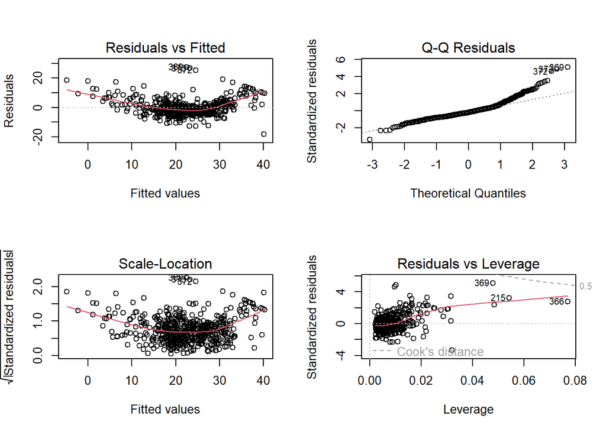

```r
# Interaction between lstat and age
fit.int <- lm(medv ~ lstat * age, data = Boston)

# Polynomial regression (degree 3)
fit.poly <- lm(medv ~ poly(lstat, 3), data = Boston)

# Diagnostics
par(mfrow = c(2, 2))
plot(fit)
```

# Chapter 4 - Classification Methods

```r
# Prepare data
data(Default)
set.seed(1)
train_idx <- sample(1:nrow(Default), 0.7 * nrow(Default))
train_data <- Default[train_idx, ]
test_data  <- Default[-train_idx, ]
```

### Logistic Regression

- Binary classifications
- Produces probabilities of landing in a class
- Interpretabble coefficients (log odds)

```r
log.fit <- glm(default ~ balance + income, data = train_data, family = binomial)
summary(log.fit)
```

```
##
## Call:
## glm(formula = default ~ balance + income, family = binomial,
##     data = train_data)
##
## Coefficients:
##               Estimate Std. Error z value Pr(>|z|)
## (Intercept) -1.167e+01  5.214e-01 -22.379  < 2e-16 ***
## balance      5.574e-03  2.678e-04  20.816  < 2e-16 ***
## income       2.560e-05  6.012e-06   4.258 2.06e-05 ***
## ---
## Signif. codes:  0 '***' 0.001 '**' 0.01 '*' 0.05 '.' 0.1 ' ' 1
##
## (Dispersion parameter for binomial family taken to be 1)
##
##     Null deviance: 2030.3  on 6999  degrees of freedom
## Residual deviance: 1079.6  on 6997  degrees of freedom
## AIC: 1085.6
##
## Number of Fisher Scoring iterations: 8
```

```r
probs <- predict(log.fit, test_data, type = "response")
preds <- ifelse(probs > 0.5, "Yes", "No")

# Accuracy
mean(preds == test_data$default)
```

```
## [1] 0.9733333
```

### Linear Discriminant Analysis (LDA)

- Classification when classes are well seperated
- Assumes predicators are normally dist
- Works better than logistic regression when $n$ is small
- Works when deicision boundaries are linear

```r
lda.fit <- lda(default ~ balance + income, data = train_data)
lda.pred <- predict(lda.fit, test_data)$class

mean(lda.pred == test_data$default)
```

```
## [1] 0.9703333
```

### Quadratic Discriminant Analysis (QDA)

- Like LDA but allows each class its own covariance
- Flexible, works when decision boundaries are nonlinear

```r
qda.fit <- qda(default ~ balance + income, data = train_data)
qda.pred <- predict(qda.fit, test_data)$class

mean(qda.pred == test_data$default)
```

```
## [1] 0.9716667
```

### Naive Bayes

- Classifier assuming independece of predictors
- Works well with many predictors
- Good for text data

```r
nb.fit <- naiveBayes(default ~ balance + income, data = train_data)
nb.pred <- predict(nb.fit, test_data)

mean(nb.pred == test_data$default)
```

```
## [1] 0.9713333
```

### K-Nearest Neighbors (KNN)

- Nonparametric classification
- Good when decision boundary is irregular
- Must scale/normalize data!

```r
# Scale numeric predictors for KNN
train.X <- scale(train_data[, c("balance", "income")])
test.X  <- scale(test_data[, c("balance", "income")])
train.Y <- train_data$default

knn.pred <- knn(train.X, test.X, train.Y, k = 5)

mean(knn.pred == test_data$default)
```

```
## [1] 0.9723333
```

# Chapter 5 - Resampling Methods

### Validation Set Approach

- Split into train and test set
- Only trains on 50-70% of data (high variance)
- The model is trained on the training set and evaluated on the validation set.

```r
set.seed(1)
train.idx <- sample(1:nrow(Boston), nrow(Boston)/2)
train <- Boston[train.idx, ]
test  <- Boston[-train.idx, ]

fit <- lm(medv ~ ., data = train)
pred <- predict(fit, newdata = test)
mean((test$medv - pred)^2) # Test MSE
```

```
## [1] 27.64986
```

### Leave-One-Out Cross Validation (LOOCV)

- A special case of k-fold cross-validation where $k = n$
- Each observation is left out one at a time. Train model on $n−1$ observations, then test on the one left out observation. Average the prediction errors
- Use with small data sets, low bias and possible high variance

```r
# cv.glm works with glm objects
fit.glm <- glm(medv ~ lstat + age, data = Boston)
loocv.err <- cv.glm(Boston, fit.glm)

loocv.err$delta[1] # Raw CV error
```

```
## [1] 38.59616
```

### k-Fold Cross Validation

- The data is divided into $k$ equal-sized folds
- Split data into $k$ groups and train model on $k-1$ folds. Test on remaining folds and repeat until each fold has been used as the validation set. Then average the errors.
- Typical $k = 5$ or $k = 10$
- Use with moderate data sets, good balance between bias and variance

```r
set.seed(1)
cv.err <- cv.glm(Boston, fit.glm, K = 10)
cv.err$delta[1]
```

```
## [1] 38.59448
```

### Bootstrap

- Bootstrap repeatedly samples observations with replacement from the dataset to create many simulated datasets called bootstrap samples
- Sample n observations with replacement, then fit model and compute statistic of interest (mean, median, CI, errors, bias, etc). Repeat process many times.

```r
boot.fn <- function(data, index) {
  coef(lm(medv ~ lstat + age, data = data, subset = index))
}

boot(Boston, boot.fn, R = 1000)
```

```
##
## ORDINARY NONPARAMETRIC BOOTSTRAP
##
##
## Call:
## boot(data = Boston, statistic = boot.fn, R = 1000)
##
##
## Bootstrap Statistics :
##        original        bias    std. error
## t1* 33.22276053 -0.0080353985  0.73322727
## t2* -1.03206856  0.0034774294  0.07701982
## t3*  0.03454434 -0.0007750115  0.01713020
```

# Chapter 6 - Model Selection and Regularization

## Select Subset of Predictors Methods

### Best Subset Selection

- Best subset selection fits all possible models using every combination of predictors and selects the best model for each model size
- Use when the number of predictors p is small
- Uses Cp, BIC, adj-$R^2$

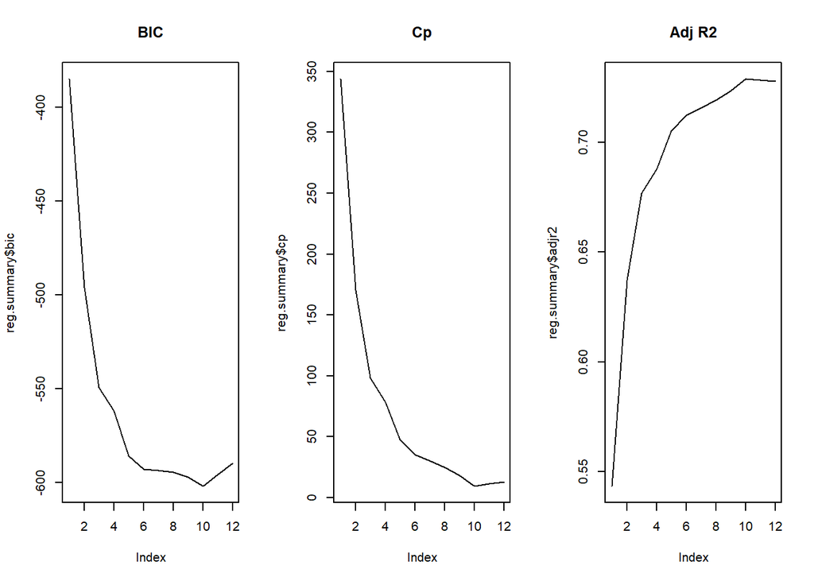

```r
# Using Boston data to predict medv
regfit <- regsubsets(medv ~ ., data = Boston, nvmax = 13)
reg.summary <- summary(regfit)

par(mfrow = c(1, 3))
plot(reg.summary$bic, type = "l", main = "BIC")
plot(reg.summary$cp, type = "l", main = "Cp")
plot(reg.summary$adjr2, type = "l", main = "Adj R2")
```

```r
# Identify the best model according to BIC
which.min(reg.summary$bic)
```

```
## [1] 10
```

### Forward / Backward Stepwise Selection

- Forward selection starts with no predictors and adds predictors one at a time
- Use forward selection when p is moderately large and works even when $p > n$
- Backward selection starts with the full model containing all predictors and removes the least useful predictor at each step
- Use backward selection when p is moderate and works only when $n > p$
- Both may miss the optimal model, depends on the order variables are added

```r
reg.fwd <- regsubsets(medv ~ ., data = Boston, nvmax = 13, method="forward")

reg.bwd <- regsubsets(medv ~ ., data = Boston, nvmax = 13, method="backward")
```

## Shrink Coefficient Methods

### Ridge Regression

- Ridge regression modifies least squares by adding a penalty on the squared size of coefficients
- Use with many predictors and possible multicollinearity
- You want coefficients to shrink towards zero but not be removed
- Use when many predictors exist and they are highly correlated. We can reduce variance without removing predictors
- Reduces overfitting and handles multicollinearity well

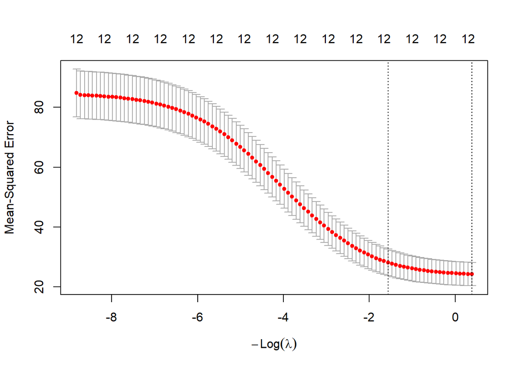

```r
# Prepare matrix input
X <- model.matrix(medv ~ ., data = Boston)[, -1]
y <- Boston$medv

# Ridge (alpha = 0)
cv.ridge <- cv.glmnet(X, y, alpha = 0)
plot(cv.ridge)
```

```r
# Coefficients for best Lasso model
best.lambda <- cv.ridge$lambda.min
predict(cv.ridge, s = best.lambda, type = "coefficients")
```

```
## 13 x 1 sparse Matrix of class "dgCMatrix"
##               s=0.6777654
## (Intercept)  32.751149447
## crim         -0.100336258
## zn            0.032827923
## indus        -0.044165780
## chas          3.039078301
## nox         -12.715946236
## rm            3.899711111
## age          -0.001878906
## dis          -1.126495302
## rad           0.139516293
## tax          -0.006197994
## ptratio      -0.842522564
## lstat        -0.494019020
```

### Lasso

- Lasso adds a penalty based on the absolute value of coefficients, this penalty can shrink some coefficients exactly to zero
- Use when you believe only a subset of predictors are important
- Can behave unpredictably when predictors are highly correlated

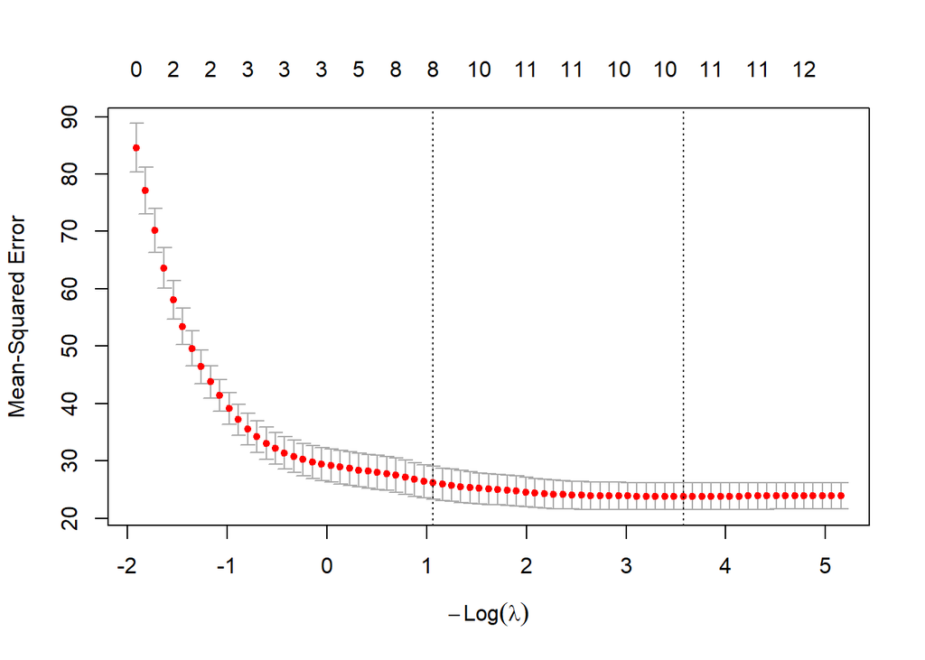

```r
# Lasso (alpha = 1)
cv.lasso <- cv.glmnet(X, y, alpha = 1)
plot(cv.lasso)
```

```r
# Coefficients for best Lasso model
best.lambda <- cv.lasso$lambda.min
predict(cv.lasso, s = best.lambda, type = "coefficients")
```

```
## 13 x 1 sparse Matrix of class "dgCMatrix"
##             s=0.02800535
## (Intercept)  39.42199459
## crim         -0.11151309
## zn            0.04180164
## indus         .
## chas          2.83267583
## nox         -17.18579053
## rm            3.73963386
## age           .
## dis          -1.41918032
## rad           0.23785169
## tax          -0.01032151
## ptratio      -0.91524475
## lstat        -0.54588257
```

```r
coef(cv.lasso, s=best.lambda)
```

```
## 13 x 1 sparse Matrix of class "dgCMatrix"
##             s=0.02800535
## (Intercept)  39.42199459
## crim         -0.11151309
## zn            0.04180164
## indus         .
## chas          2.83267583
## nox         -17.18579053
## rm            3.73963386
## age           .
## dis          -1.41918032
## rad           0.23785169
## tax          -0.01032151
## ptratio      -0.91524475
## lstat        -0.54588257
```

## Dimension Reduction Methods

### Principal Components Regression (PCR)

- PCR first performs principal component analysis (PCA) on the predictors and then performs regression using the principal components instead of the original variables
- The components capture the directions of greatest variance in the predictors
- Use PCR when predictors are highly correlated, p is large, and we want to reduce dimensionality before regression

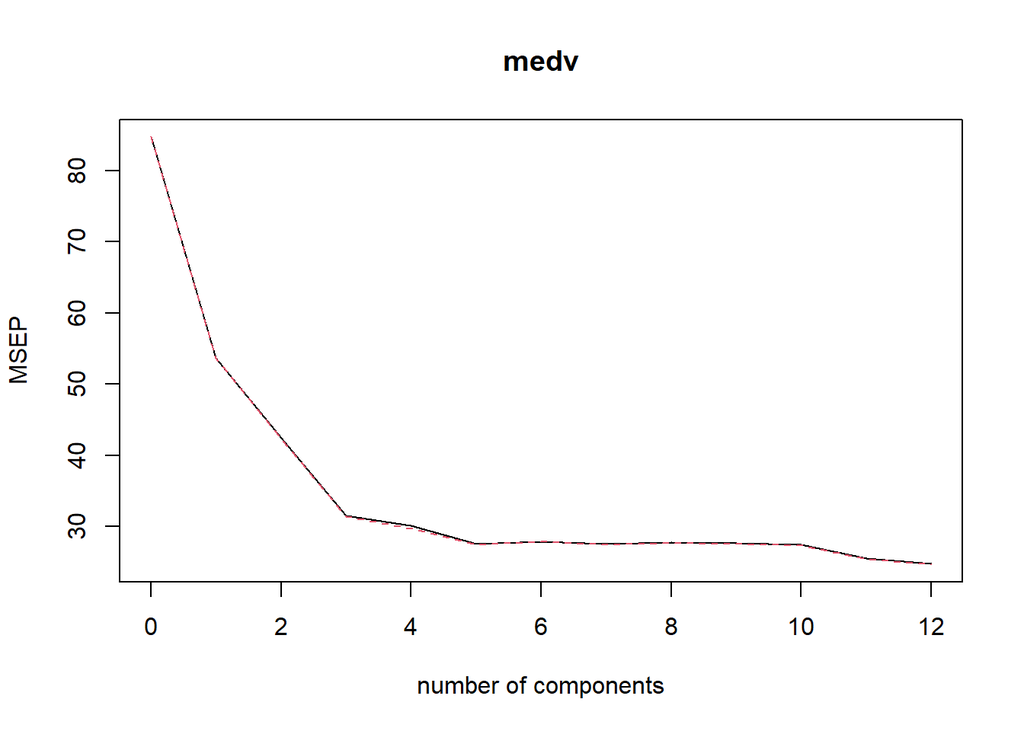

```r
# PCR
pcr.fit <- pcr(medv ~ ., data = Boston, scale = TRUE, validation = "CV")
validationplot(pcr.fit, val.type = "MSEP")
```

### Partial Least Squares (PLS)

- PLS is similar to PCR but differs because it chooses components using both predictors and the response variable
- This means the components are selected to maximize covariance with the response
- Use PLS when the predictors are highly correlated, you want dimension reduction, and you want components that directly help predict Y

```r
# PLS
pls.fit <- plsr(medv ~ ., data = Boston, scale = TRUE, validation = "CV")
summary(pls.fit)
```

```
## Data:    X dimension: 506 12
##  Y dimension: 506 1
## Fit method: kernelpls
## Number of components considered: 12
##
## VALIDATION: RMSEP
## Cross-validated using 10 random segments.
##        (Intercept)  1 comps  2 comps  3 comps  4 comps  5 comps  6 comps
## CV           9.206    6.581    5.159    5.070    5.004    4.961    4.918
## adjCV        9.206    6.578    5.154    5.062    4.992    4.949    4.909
##        7 comps  8 comps  9 comps  10 comps  11 comps  12 comps
## CV       4.915    4.916    4.912     4.915     4.915     4.915
## adjCV    4.906    4.906    4.903     4.905     4.905     4.905
##
## TRAINING: % variance explained
##       1 comps  2 comps  3 comps  4 comps  5 comps  6 comps  7 comps  8 comps
## X       47.81    59.71    67.51    72.82    79.09    82.22    86.00    89.95
## medv    49.84    69.90    71.58    72.75    73.15    73.30    73.38    73.42
##       9 comps  10 comps  11 comps  12 comps
## X       92.88     96.16     98.27    100.00
## medv    73.43     73.43     73.43     73.43
```

# Chapter 7 - Moving Beyond Linearity

### Polynomial Regression and Step Functions

- Polynomials: Extending linear models by adding extra predictors (powers of X).
- Step Functions: Breaking the range of X into bins.

```r
# Polynomial Regression (Degree 4)
fit.poly <- lm(medv ~ poly(lstat, 4), data = Boston)

# Step Functions
table(cut(Boston$lstat, 4)) # Create 4 bins
```

```
##
## (1.69,10.8] (10.8,19.9] (19.9,28.9]   (28.9,38]
##         243         187          57          19
```

```r
fit.step <- lm(medv ~ cut(lstat, 4), data = Boston)
```

### Splines and GAMs

- Regression Splines: Piecewise polynomials joined at “knots.”
- Smoothing Splines: Minimizes RSS with a roughness penalty.
- GAMs (Generalized Additive Models): Allows for non-linear functions of multiple predictors.

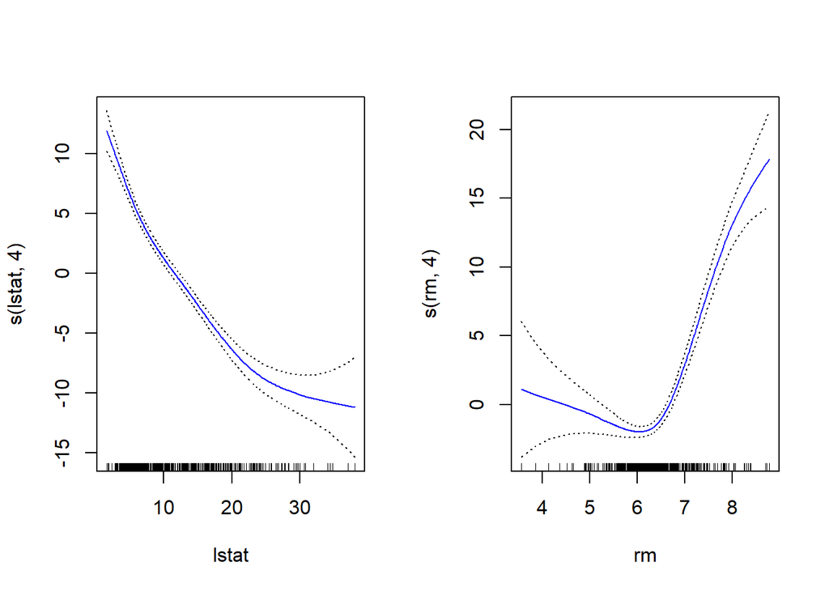

```r
library(splines)
library(gam)

# Regression Spline with specified knots
fit.spline <- lm(medv ~ bs(lstat, knots = c(10, 20, 30)), data = Boston)

# GAM using Smoothing Splines (s)
fit.gam <- gam(medv ~ s(lstat, 4) + s(rm, 4), data = Boston)
par(mfrow = c(1, 2))
plot(fit.gam, se = TRUE, col = "blue")
```

# Chapter 8 - Tree-Based Methods

### Decision Trees

Simple, interpretable, but prone to overfitting.

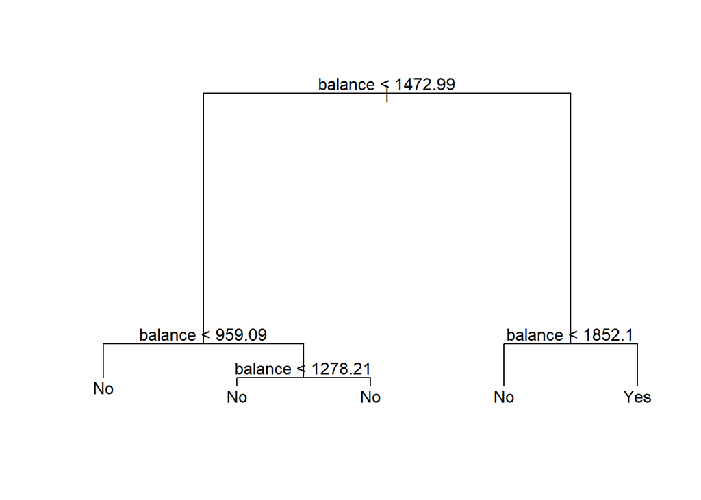

```r
library(tree)

# Classification Tree
tree.default <- tree(default ~ ., data = train_data)
plot(tree.default)
text(tree.default, pretty = 0)
```

```r
# Pruning
cv.default <- cv.tree(tree.default, FUN = prune.misclass)
prune.default <- prune.misclass(tree.default, best = 5)
```

### Bagging and Random Forests

- Bagging: Building multiple trees from bootstrapped samples and averaging them.
- Random Forest: Like bagging, but decorrelates trees by only considering a subset of predictors at each split.

```r
library(randomForest)

# Bagging (mtry = total number of predictors)
bag.boston <- randomForest(medv ~ ., data = Boston, mtry = 13, importance = TRUE)

# Random Forest (mtry = default is p/3 for regression, sqrt(p) for class)
rf.boston <- randomForest(medv ~ ., data = Boston, importance = TRUE)
importance(rf.boston)
```

```
##           %IncMSE IncNodePurity
## crim    16.201338     2487.5862
## zn       4.625411      251.4188
## indus   10.847563     2356.3199
## chas     4.186028      224.4417
## nox     19.240841     2738.0047
## rm      39.126209    12998.4307
## age     16.891060     1088.8645
## dis     17.808276     2535.1569
## rad      6.784053      341.1670
## tax     12.036231     1329.0943
## ptratio 15.050980     2856.7958
## lstat   31.101153    12831.2565
```

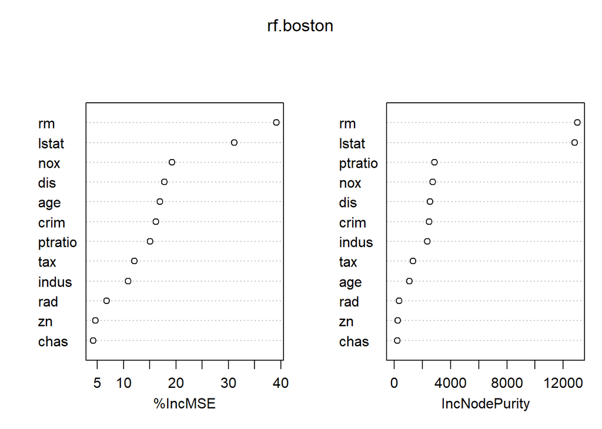

```r
varImpPlot(rf.boston)
```

### Boosting

Builds trees sequentially; each tree learns from the residuals of the previous ones.

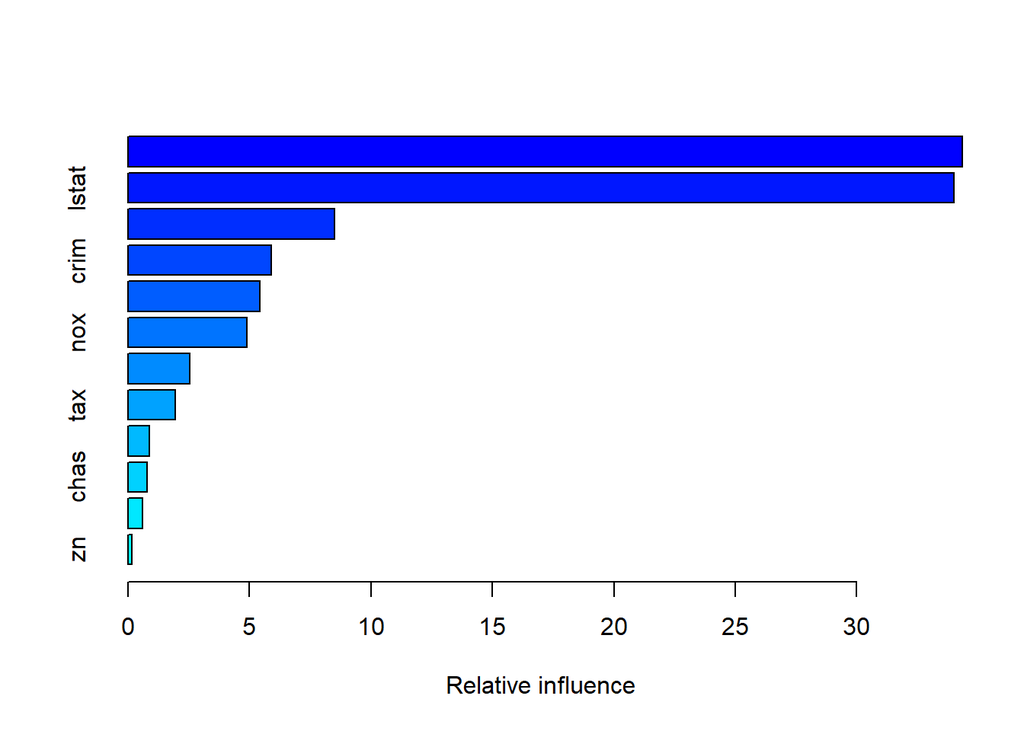

```
##             var    rel.inf
## rm           rm 34.3427524
## lstat     lstat 33.9951083
## dis         dis  8.5011557
## crim       crim  5.9045913
## age         age  5.4226378
## nox         nox  4.9015937
## ptratio ptratio  2.5563881
## tax         tax  1.9562686
## indus     indus  0.8836519
## chas       chas  0.7806415
## rad         rad  0.5848528
## zn           zn  0.1703579
```

```r
library(gbm)

# Boosting (Distribution "gaussian" for regression, "bernoulli" for binary class)
boost.boston <- gbm(medv ~ ., data = Boston, distribution = "gaussian",
                    n.trees = 5000, interaction.depth = 4)

summary(boost.boston) # Variable importance
```

# Chapter 9 - Support Vector Machines

### Support Vector Classifier

Linear boundary: uses a “cost” parameter to allow for observations to be on the wrong side of the margin.

```r
library(e1071)

# Linear kernel
svc.fit <- svm(default ~ balance + income, data = train_data,
               kernel = "linear", cost = 10, scale = TRUE)

# Cross-validation to find best cost
tune.out <- tune(svm, default ~ balance + income, data = train_data,
                 kernel = "linear", ranges = list(cost = c(0.1, 1, 10)))
best.svc <- tune.out$best.model
```

### Support Vector Machines (SVM)

Uses kernels (Radial, Polynomial) to create non-linear decision boundaries.

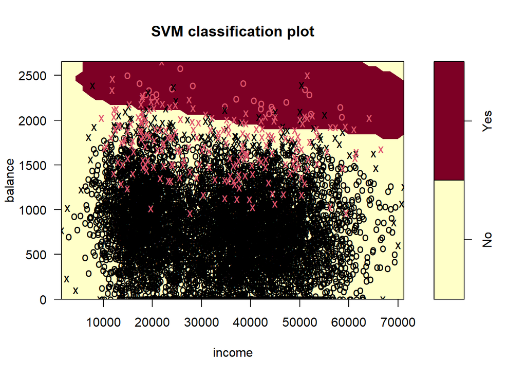

```r
# Radial Kernel
svm.radial <- svm(default ~ balance + income, data = train_data,
                  kernel = "radial", gamma = 1, cost = 1)

# Plotting the boundary (Note: only works for 2 predictors)
plot(svm.radial, train_data, balance ~ income)
```

```r
# Predictions
svm.pred <- predict(svm.radial, test_data)
table(predict = svm.pred, truth = test_data$default)
```

```
##        truth
## predict   No  Yes
##     No  2896   86
##     Yes    2   16
```